# Charakterisierung der konvektiven Wolke zum Zeitpunkt mit Z=35 dBZ

Um ein Verständnis für eine gute Objektdefinition und die Wolkeneigenschaften zum Zeitpunkt des ersten Niederschlagssignals zu erhalten betrachten wir den Zeitpunkt mit Z=35dBZ in den Tracks der HACI-Objekte des Jahres 2013.

```python
import sys
import numpy as np
import pandas as ps
import xarray as xr
import matplotlib.pyplot as plt
%matplotlib inline

import glob

from analysis_tools import make_hrv_upscaling as mhu
import scipy.ndimage as ndi
```

```python
data_path = "/vols/talos/home/stephan/data/radar_track/trackdata/"
```

Zunächst laden wir uns die Pfade aller Dateien mit den Trackdaten.

```python
track_paths = glob.glob("{path}/*.nc".format(path=data_path))
```

```python
print track_paths[0:10]
```

```
['/vols/talos/home/stephan/data/radar_track/trackdata/haci_trackdata_20130722_45.nc', '/vols/talos/home/stephan/data/radar_track/trackdata/haci_trackdata_20130722_71.nc', '/vols/talos/home/stephan/data/radar_track/trackdata/haci_trackdata_20130722_93.nc', '/vols/talos/home/stephan/data/radar_track/t…
```

Dann sehen wir uns mal ein Beispiel an.

```python
track_data = xr.open_dataset(track_paths[0])
```

```python
track_data
```

```
<xarray.Dataset>
Dimensions:  (hx: 153, hy: 153, rx: 194, ry: 170, time: 13, x: 51, y: 51)
Coordinates:
    hlat     (hx, hy) float64 48.76 48.76 48.76 48.76 48.76 48.76 48.76 ...
    rlon     (rx, ry) float64 5.869 5.881 5.894 5.906 5.918 5.93 5.943 5.955 ...
    lon      (x, y) float32 5.6908774 5.7342663 5.777671 5.821074 5.864476 ...
    hlon     (hx, hy) float64 5.659 5.673 5.688 5.702 5.717 5.731 5.746 5.76 ...
  * time     (time) datetime64[ns] 2013-07-22T15:25:00 2013-07-22T15:30:00 ...
    lat      (x, y) float32 48.722813 48.722504 48.72205 48.721577 48.72109 ...
    rlat     (rx, ry) float32 47.095997 47.096596 47.097195 47.097794 ...
Dimensions without coordinates: hx, hy, rx, ry, x, y
Data variables:
    ir016    (time, x, y) float64 0.1595 0.1292 0.1688 0.1944 0.1956 0.2189 ...
    ir134    (time, x, y) float64 228.2 234.1 234.2 231.0 231.7 231.4 230.2 ...
    ir039    (time, x, y) float64 270.6 272.2 262.2 252.7 250.7 251.4 252.1 ...
    hrv      (time, hx, hy) float64 0.253 0.2373 0.2094 0.1671 0.1392 0.1574 ...
    cma      (time, x, y) float32 2.0 2.0 3.0 3.0 3.0 3.0 3.0 2.0 2.0 2.0 ...
    wv062    (time, x, y) float64 222.7 225.0 226.3 226.6 227.0 227.0 226.0 ...
    ir120    (time, x, y) float64 235.5 244.2 240.0 234.1 235.0 233.8 232.1 ...
    wv073    (time, x, y) float64 227.0 233.3 233.9 231.0 231.5 230.8 229.3 ...
    ch       (time, x, y) float32 11000.0 11000.0 9400.0 9600.0 9600.0 ...
    vis006   (time, x, y) float64 0.2083 0.1652 0.2223 0.2904 0.3174 0.3535 ...
    ir108    (time, x, y) float64 241.2 248.6 241.0 234.5 235.5 234.2 233.7 ...
    vis008   (time, x, y) float64 0.2733 0.2136 0.2527 0.3388 0.3687 0.4054 ...
    ir087    (time, x, y) float64 241.6 250.7 243.9 235.0 235.5 234.2 233.1 ...
    ir097    (time, x, y) float64 235.6 239.7 237.8 234.3 233.8 233.8 233.1 ...
    z        (time, rx, ry) float64 92.5 92.5 92.5 92.5 92.5 92.5 92.5 92.5 ...
    fld      (time, hx, hy) float64 0.0 0.0 0.0 0.0 0.0 0.0 0.0 0.0 0.0 0.0 ...
Attributes:
    title:    MSG, Radolan and Linet data for HACI object track 45 on 2013-07-22
```

Wie interessieren uns für den Zeitschritt wo das erste mal Z=35 dBZ erreicht wird. Das ist der siebente Zeitschritt.

```
Text(0.5,1,u'RADOLAN RX')
```

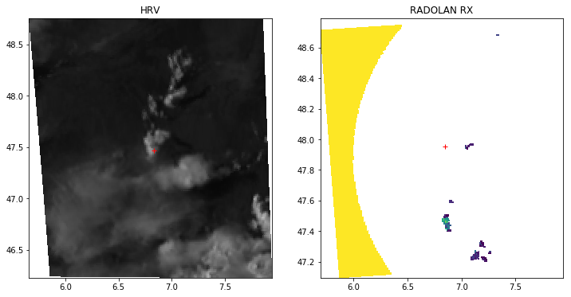

```python
fig,ax = plt.subplots(1,2,figsize=(12,6))
ax[0].pcolormesh(track_data.hlon.data,track_data.hlat.data,
                 track_data.hrv.data[7],
                 vmin=0,vmax=1,cmap='gray')
ax[0].plot(track_data.hlon.data[track_data.hlon.data.shape[0]//2,
                                track_data.hlon.data.shape[1]//2],
           track_data.hlat.data[track_data.hlat.data.shape[0]//2,
                                track_data.hlat.data.shape[1]//2],
           'r+')
ax[0].set_title(u"HRV")

ax[1].pcolormesh(track_data.rlon.data,track_data.rlat.data,
                 np.ma.masked_less(track_data.z.data[7],35),
              vmin=35,vmax=65)
ax[1].plot(track_data.rlon.data[track_data.rlon.data.shape[0]//2,
                                track_data.rlon.data.shape[1]//2],
           track_data.rlat.data[track_data.rlat.data.shape[0]//2,
                                track_data.rlat.data.shape[1]//2],
           'r+')
ax[1].set_title(u"RADOLAN RX")
```

Wir haben hier ein Wolkenfeld mit mehren konvektiven Wolken, die Niederschlag produzieren. Uns interessiert aber nur die Wolke in der Mitte des Ausschnitts.

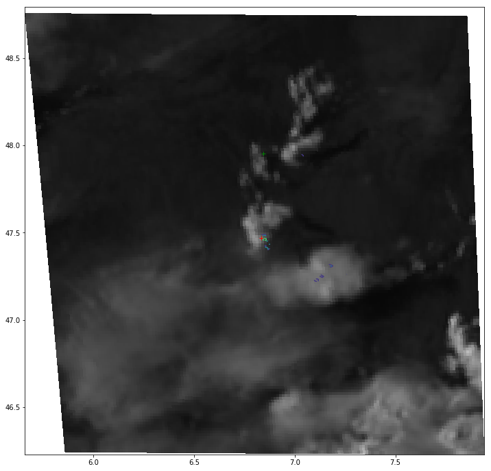

```python
fig,ax = plt.subplots(1,1,figsize=(12,12))
ax.pcolormesh(track_data.hlon.data,track_data.hlat.data,
                 track_data.hrv.data[7],
                 vmin=0,vmax=1,cmap='gray')
ax.plot(track_data.hlon.data[track_data.hlon.data.shape[0]//2,
                                track_data.hlon.data.shape[1]//2],
           track_data.hlat.data[track_data.hlat.data.shape[0]//2,
                                track_data.hlat.data.shape[1]//2],
           'r+')
ax.contour(track_data.rlon.data,track_data.rlat.data,
           np.ma.masked_less(track_data.z.data[7],35),
           vmin=35,vmax=65)
ax.plot(track_data.rlon.data[track_data.rlon.data.shape[0]//2,
                                track_data.rlon.data.shape[1]//2],
           track_data.rlat.data[track_data.rlat.data.shape[0]//2,
                                track_data.rlat.data.shape[1]//2],
           'g+')
```

Mal sehen, ob wir diese Wolke vom Rest trennen können, um ihre Eigenschaften zu berachten.

```python
cma_hrv = mhu.make_hrv_upscaling(track_data.cma[7].data)
```

```python
hrv_masked = np.ma.masked_where(cma_hrv<2, track_data.hrv[7].data)
```

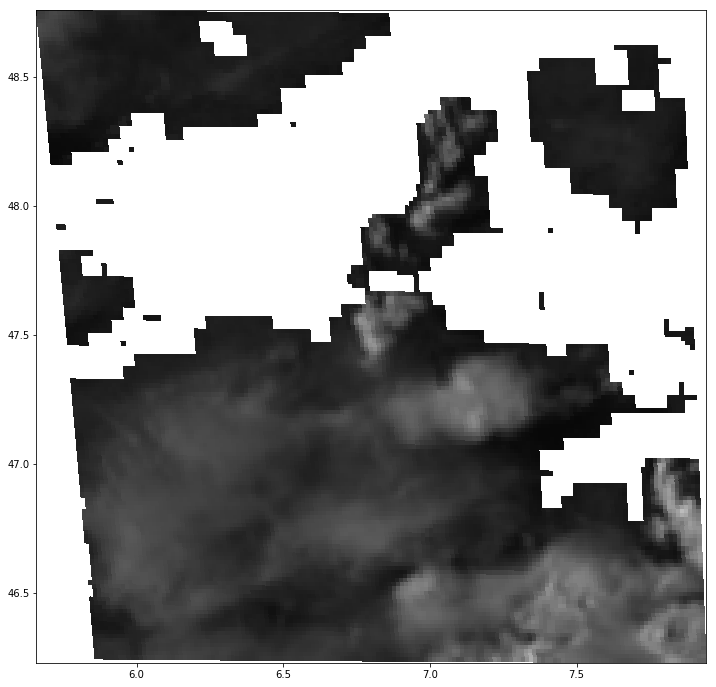

```python
fig,ax = plt.subplots(1,1,figsize=(12,12))
ax.pcolormesh(track_data.hlon.data,track_data.hlat.data,
               hrv_masked,
                 vmin=0,vmax=1,cmap='gray')
```

Das sieht schonmal garnicht so schlecht aus. Am besten sehen wir uns mal ein Histogramm der Reflektanz dess Ausschnittes an, um eventuell einen geeigneten Schwellwert zu finden.

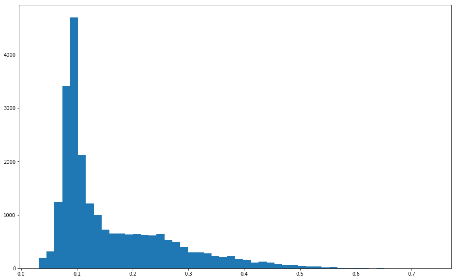

```python
fig,ax = plt.subplots(1,1,figsize=(16,10))
ax.hist(hrv_masked.ravel(),bins=50)
```

Es ist kein eindeutiger Wert erkennbar, aber vielleicht hilft eine Glättung.

```python
hrv_smooth = ndi.filters.gaussian_filter(track_data.hrv[7].data,2)
```

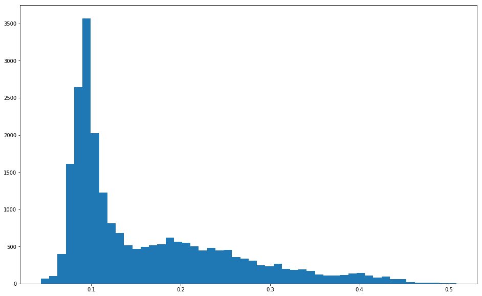

```python
fig,ax = plt.subplots(1,1,figsize=(16,10))
bv= ax.hist(hrv_smooth.ravel(),bins=50)
```

Das hilft auch nicht weiter. Dann versuchen wir es mal mit einer Iteration über mögliche Schwellwerte.

```python
hrv_thresholds = np.arange(0,1,0.1)

hrv_m = dict()

for ht in hrv_thresholds:
    hrv_m[ht] = np.ma.masked_less(hrv_smooth,ht)
```

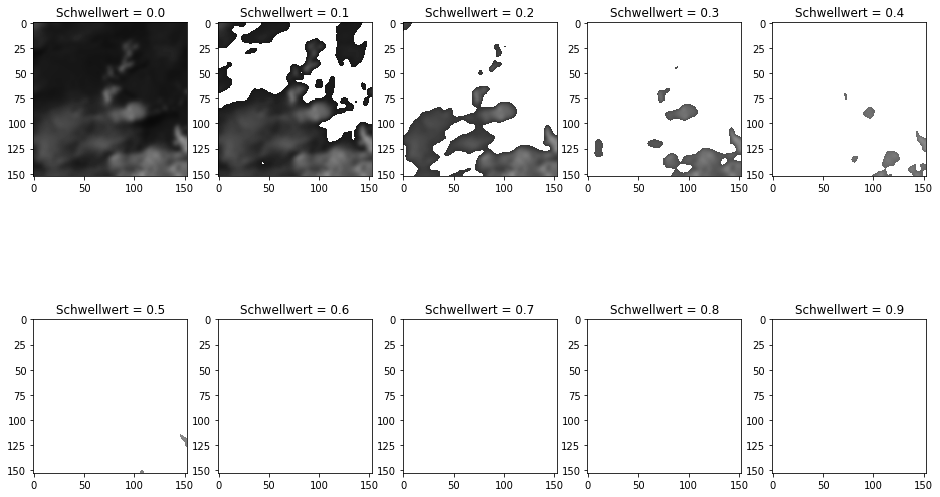

```python
fig,ax = plt.subplots(2,5,figsize=(16,10))
axs = ax.ravel()

for i,k in enumerate(sorted(hrv_m.keys())):
    axs[i].imshow(hrv_m[k],vmin=0,vmax=1,cmap='gray')
    axs[i].set_title(u"Schwellwert = {th}".format(th=k))
```

Es sieht so aus, als könnten 0,2 oder 0,3 vernünftige Schwellwerte sein. Bei 0,3 sind die Wolkenobjekte besser trennbar, aber man erhält nur die inneren Wolkenbereiche. Eventuell kann hier ein Hystereseschwellwertverfahren weiterhelfen.

```python
sys.path.append("/vols/talos/home/stephan/utils/tracking/")
import object_tracking as ot
```

```python
hrv_seg = ot.apply_hysteresis_threshold(hrv_smooth,0.3,0.4)
```

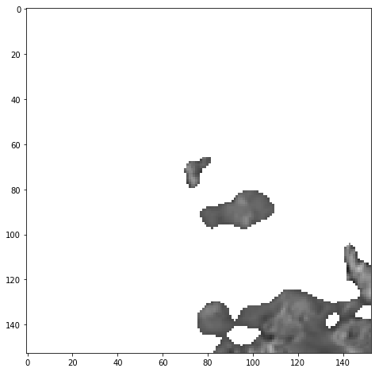

```python
fig,ax = plt.subplots(1,1,figsize=(8,8))
ax.imshow(np.ma.masked_where(hrv_seg<1,track_data.hrv[7].data),vmin=0,vmax=1,cmap='gray')
```

Als nächstes markieren wir die Objekte.

```python
object_labels, nobject = ndi.label(hrv_seg)
```

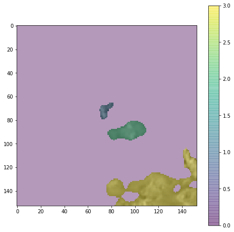

```python
fig,ax = plt.subplots(1,1,figsize=(8,8))
ax.imshow(np.ma.masked_where(hrv_seg<1,track_data.hrv[7].data),vmin=0,vmax=1,cmap='gray')
lab_plot = ax.imshow(object_labels,alpha=0.4)
fig.colorbar(lab_plot)
```

Das Objekt mit der Markierung 1 scheint unser gesuches Objekt zu sein.

```python
objekt_mask = np.ma.masked_less(np.ma.masked_greater(object_labels,1),1)
```

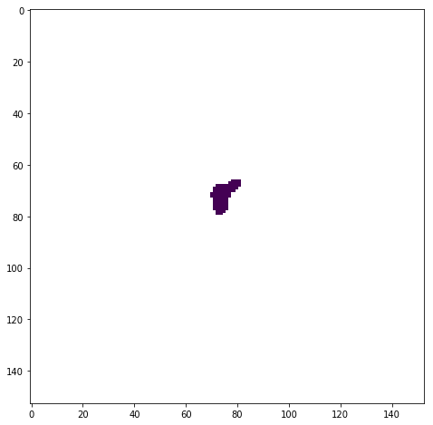

```python
fig,ax = plt.subplots(1,1,figsize=(8,8))
ax.imshow(objekt_mask)
```

Als nächstes schneiden wir diesen Bereich auch aus anderen Daten als dem HRV-Kanal aus und sehen uns an, wie diese Daten aussehen.

```python
import geooperations as go
objekt_mask_lowres = go.remap_grid(objekt_mask,track_data.hlon.data,track_data.hlat.data,track_data.lon.data,
                                   track_data.lat.data,1)
objekt_mask_rado = go.remap_grid(objekt_mask,track_data.hlon.data,track_data.hlat.data,track_data.rlon.data,
                                   track_data.rlat.data,1)
```

```
Text(0.5,1,u'Objektmaske, RADOLAN-Aufl\xf6sung')
```

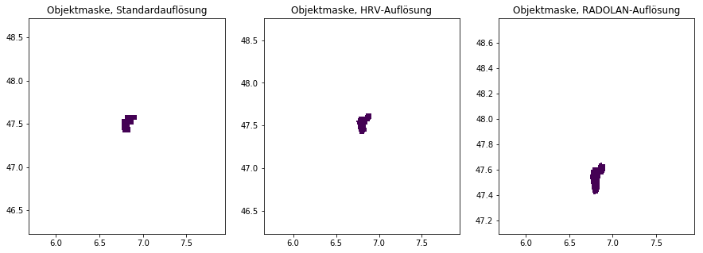

```python
fig,ax = plt.subplots(1,3,figsize=(15,5))
ax[0].pcolormesh(track_data.lon.data,track_data.lat.data,objekt_mask_lowres)
ax[0].set_title(u"Objektmaske, Standardauflösung")
ax[1].pcolormesh(track_data.hlon.data,track_data.hlat.data,objekt_mask)
ax[1].set_title(u"Objektmaske, HRV-Auflösung")
ax[2].pcolormesh(track_data.rlon.data,track_data.rlat.data,objekt_mask_rado)
ax[2].set_title(u"Objektmaske, RADOLAN-Auflösung")
```

```python
cutouts = dict()

for k in track_data.keys():
    if k not in ['hlat','hlon','rlat','rlon','lat','lon','time']:
        if k in ['hrv','fld']:
            mask = objekt_mask
        elif k in ['z']:
            mask = objekt_mask_rado
        else:
            mask = objekt_mask_lowres

        cutouts[k] = np.ma.masked_where(mask!=1,track_data[k].data[7]).ravel()
```

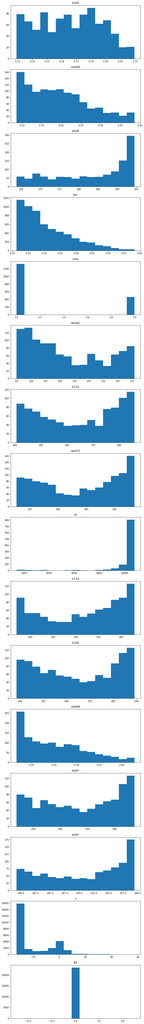

```python
fig,ax = plt.subplots(len(cutouts.keys()),1,figsize=(10,5*len(cutouts.keys())))
axs=ax.ravel()
mean_properties = dict()
min_properties = dict()
max_properties = dict()
for i,k in enumerate(cutouts.keys()):
    bv,axs[i].hist(cutouts[k],bins=15)
    axs[i].set_title(k)

    mean_properties[k] = np.nanmean(cutouts[k])
    max_properties[k] = np.nanmax(cutouts[k])
    min_properties[k] = np.nanmin(cutouts[k])
```

```python
print ("min: {}\n\nmean: {}\n\nmax: {}".format(min_properties, mean_properties, max_properties))
```

```
min: {u'ir016': 0.12923314129752464, u'ir134': 237.01999433144547, u'ir039': 263.779743552512, u'hrv': 0.2130677120463539, u'cma': 2.0, u'wv062': 224.992971329802, u'ir120': 240.64148910163112, u'wv073': 232.64390262558123, u'ch': 1400.0, u'vis006': 0.08611181731861789, u'ir108': 238.5582030577708, …

mean: {u'ir016': 0.1657909848717794, u'ir134': 252.60277919988965, u'ir039': 283.83192776106716, u'hrv': 0.40314709951627803, u'cma': 2.6, u'wv062': 230.6137722091665, u'ir120': 268.4109032305167, u'wv073': 246.33419605643138, u'ch': 6840.0, u'vis006': 0.21097395243061373, u'ir108': 269.731700980847…

max: {u'ir016': 0.2095672561581481, u'ir134': 262.92129903714135, u'ir039': 294.53785784824703, u'hrv': 0.5835149841269465, u'cma': 3.0, u'wv062': 233.171551856155, u'ir120': 286.0042245700893, u'wv073': 253.59321825316468, u'ch': 10800.0, u'vis006': 0.38650187773240113, u'ir108': 289.26913322026536…
```